# Predictive Modeling of Residential Property Prices

Pierce County Project

Edberto, Gerta, Helga, & Mira

2026-05-11

# Project Objective

## Background & Motivation

Estimating house prices is a classic regression problem with clear real-world importance. Housing markets are influenced by many interconnected factors, including property characteristics, location, neighborhood effects, and market trends over time. Because nearby properties often share similar values and market conditions change continuously, house-price prediction provides an excellent example for applying the complete data-science workflow covered in this course.

For this project, the publicly available Assessor–Treasurer data from Pierce County is used as the main data source. The dataset contains detailed and realistic information about properties, transactions, and assessments across multiple linked tables, offering a large-scale and practical environment for data exploration, pre-processing, feature engineering, and predictive modeling.

## Qualitative Objectives

1. Build a clean housing dataset for Pierce County.
2. Explore which factors influence house prices.
3. Engineer predictive variables from property and spatial data.
4. Compare traditional statistical and machine learning approaches.
5. Deploy a simple Shiny app for interactive price estimation.
6. Allow non-technical users to test predictions using custom property inputs.
7. Create visual outputs that support decision-making.

## Quantitative Objectives

| Objective | Metric | Target |
| --- | --- | --- |
| **Model Accuracy** | Root Mean Square Error (RMSE) | 80% within 15% from actual price |
| **Explanatory Power** | Coefficient of Determination (R²) | > 0.85 |
| **Model Diversity** | Algorithm Benchmarking | ≥ 4 distinct algorithms |
| **Feature Richness** | Engineered Predictors | ≥ 20 model-ready features |
| **App Performance** | Real-time Inference | Response time < 3 seconds |
| **Data Integrity** | Table Integration | 100% of selected source tables joined |

## Deliverables & Timeline

- **21.05.2026**: Project Proposal Presentation
- **06.06.2026**: Interim Results Presentation
- **24.06.2026**: Final Results Presentation & Project Report Submission
- **24.06.2026**: Live demo of deployed model App

# Data Source Description & Data Dictionary

## Overview

The Pierce County Assessor–Treasurer Data Mart is a comprehensive relational database containing detailed property assessment, taxation, appraisal, land-use, improvement, and sales transaction records maintained by Pierce County, Washington. The dataset integrates information from multiple administrative systems and organizes it into interconnected tables linked primarily through the parcel identification number, enabling consistent tracking of individual properties across taxation, valuation, ownership, and structural characteristics.

The database includes information related to property accounts, land attributes, building improvements, tax assessments, exemption categories, sales history, and geographic identifiers. Together, these tables provide a multidimensional representation of residential and commercial properties and support both fiscal administration and real-estate market analysis.

## Relational Diagram

```
---
config:
  theme: 'neutral'
---
erDiagram

    TAX_ACCOUNT {
        string parcel_number PK
    }

    APPRAISAL_ACCOUNT {
        string parcel_number PK
    }

    IMPROVEMENT {
        string parcel_number PK
        string building_id PK
    }

    IMPROVEMENT_BUILTAS {
        string parcel_number PK
        string building_id PK
        string built_as_number PK
    }

    IMPROVEMENT_DETAIL {
        string parcel_number PK
        string building_id PK
        string detail_type PK
    }

    LAND_ATTRIBUTE {
        string parcel_number PK
        string attribute PK
    }

    TAX_DESCRIPTION {
        string parcel_number PK
        string line_number PK
        string tax_description_line
```

[output cut: 20 more lines]

```
    APPRAISAL_ACCOUNT ||--o{ IMPROVEMENT : "has buildings"

    IMPROVEMENT ||--|{ IMPROVEMENT_BUILTAS : "built-as types"

    IMPROVEMENT ||--o{ IMPROVEMENT_DETAIL : "details"

    APPRAISAL_ACCOUNT ||--o{ LAND_ATTRIBUTE : "land attributes"

    TAX_ACCOUNT ||--|{ TAX_DESCRIPTION : "tax descriptions"

    TAX_ACCOUNT ||--|| TAXPAYER : "taxpayer"

    TAX_ACCOUNT ||--o{ SEG_MERGE : "parcel history"

    APPRAISAL_ACCOUNT ||--o{ SALE : "sales"
```

Figure 1

## Data Dictionary Summary

1. **Tax Account**: Current tax and assessment information per parcel
2. **Appraisal Account**: Detailed property appraisal with characteristics
3. **Improvement**: Building-level details (multiple per parcel)
4. **Improvement Built-As**: Construction specifications and year built
5. **Improvement Detail**: Features (garages, decks, fireplaces, etc.)
6. **Land Attribute**: Land-specific characteristics affecting valuation
7. **Sale**: Historical property sales transactions
8. **Seg/Merge**: Property segregation and merger history
9. **Taxpayer**: Owner information (privacy restricted)

# Project Organization & Task Allocation

## Group Structure

Table 1: Project team composition and assigned roles.

| Name | Role |
| --- | --- |
| **Mira Radakovic (PL)** | Project Leader |
| **Edberto Moura Lima** | Data Analyst |
| **Gerta Hajrullahi** | Data Analyst |
| **Helga Deutschmann** | Data Analyst |

## Tools & Infrastructure

| Component | Detail |
| --- | --- |
| **Language** | R |
| **Database** | Supabase (PostgreSQL) |
| **Version Control** | Git + GitHub |
| **Project Management** | GitHub Projects + conceptboard |
| **Communication** | Group messaging + sync meetings |
| **Documentation** | Quarto |
| **Data Wrangling** | dplyr, tidyr, readr |
| **EDA & Viz** | ggplot2, corrplot, leaflet, plotly |
| **Modelling** | caret / tidymodels, ranger, xgboost, glmnet |
| **Spatial Analysis** | sf, geosphere |
| **Deployment** | Shiny, shinydashboard |

## Project Kanban Board

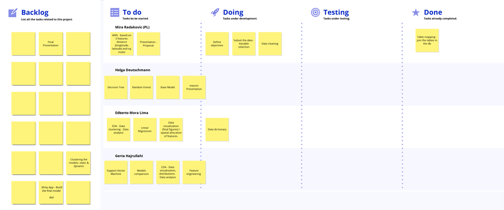

Figure 2: Project task tracking board showing workflow stages from backlog to completion.

# Development Plan Overview

## Workflow Diagram

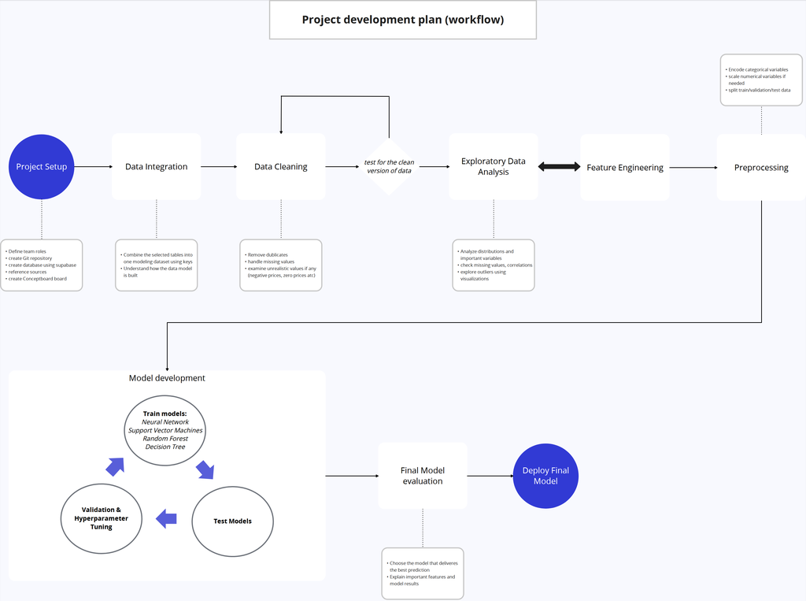

Figure 3: Project Development Workflow

## Work Package Summary

High-level work package phases and planned duration in weeks.

| WP | Phase | Duration |
| --- | --- | --- |
| WP0 | Project Setup | 13–19 May |
| WP1 | Data Integration | 20–26 May |
| WP2 | Data Cleaning | 27 May – 2 June |
| WP3 | EDA & Features | 30 May – 6 June |
| WP4 | Preprocessing | 7–9 June |
| WP5 | Model Development | 9–15 June |
| WP6 | Model Evaluation | 16–20 June |
| WP7 | Deployment | 20–24 June |

## Communication & Oversight

**Weekly Sync**:

- Review completed tasks
- Discuss blockers & dependencies
- Update Kanban board
- Plan next week

**Status Reporting**: Mira provides bi-weekly status to lecturer